# Legislation Applicable to Pacific Salmon and Ecosystems (LAPSE)

Technical Brief

Joe Enns and Cory Lagasse

2026-03-26

[Interactive App](https://dfo-pacific-science.github.io/LAPSE_dashboard/)

> ⚠️ **Disclaimer:** None of the information presented in this document qualifies as legal advice. The authors are aquatic biologists with limited legal training. This tool is intended for research and informational purposes only.

# Introduction

Stewardship of natural resources such as Pacific salmon (*Oncorhynchus* spp.) in Canada is administered through an overlapping patchwork of federal, provincial, and territorial authority. This decentralized mosaic often undermines expensive conservation efforts, especially when legislation is not considered during conservation, protection, and restoration planning. The **Legislation Applicable to Pacific Salmon and Ecosystems (LAPSE)** process and framework was developed to help unravel this complexity for salmon stewards. LAPSE is an open-source tool that maps Canadian federal and British Columbia provincial legislation to standardized human threat categories that allows practitioners to navigate the regulatory landscape specific to salmon. This document serves as the technical manual and methodology reference for the LAPSE process, database, and associated tools.

For results, discussion, and case studies, refer to the publication:

> Enns, J., Lagasse, C., Gillis, D., and Wright, M. (2026). An interface between statutes and salmon: the Legislation Applicable to Pacific Salmon and Ecosystems (LAPSE) framework. *[Journal pending]*

## LAPSE resources

🔗 LAPSE About page: https://dfo-pacific-science.github.io/LAPSE_dashboard/LAPSE-Dashboard-About.html

🔗 LAPSE Dashboard (interactive tool): https://dfo-pacific-science.github.io/LAPSE_dashboard/

🔗 LAPSE_pipeline (Git Hub) including all source code, data processing scripts, keyword lists, and the SQLite database: https://github.com/dfo-pacific-science/LAPSE_pipeline

🔗 LAPSE_dashboard source code (Git Hub): https://github.com/dfo-pacific-science/LAPSE_dashboard

# Purpose and scope

## Objectives

This framework and tool were developed to help navigate the complexity between threats to Pacific salmon and corresponding environmental legislation by creating an interface between regulatory language and anthropogenic threat categories. The specific objectives are to:

1. create a process and tool to categorize specific legislation by human threats to Pacific salmon;
2. assess legislative factors by threat categorization across federal and provincial jurisdictions; and
3. provide a framework to support systematic and critical reviews of the strengths and shortcomings of regulations with respect to salmon threats.

## What LAPSE covers

LAPSE accumulates and categorizes **Canadian federal** and **British Columbia provincial** legislation relevant to Pacific salmon and habitat stewardship. For this study, the term **legislation** (or *statutes*) refers collectively to **acts**, **regulations**, **codes**, and **orders**. The scope is limited to legislation as written; this study does not verify the implementation or enforcement of the statutes in practice.

## What LAPSE does not cover

Legislation is used as the primary unit of analysis — rather than policy — because legislation is a better indicator of a jurisdiction’s long-term commitment to natural resource stewardship (Bogetti and Mason 2025). Policies are formal statements about how the government of the day plans to execute legislative requirements and are more prone to changes in the political, administrative, and budgetary landscape, while legislation is subject to due process or a parliamentary vote. Specific departmental policy frameworks and processes were not assessed.

The following were outside the scope of this legislative review in terms of feasibility and timelines, though some may overlap with included federal or provincial legislation:

- Indigenous legislation and land claims agreements
- Yukon Territorial legislation
- Municipal bylaws
- International conventions and treaties

# Management domain framework

## IUCN–CMP threat classification background

The IUCN and the Conservation Measures Partnership (CMP) developed the IUCN–CMP Direct Threats Classification Version 4.0 (Salafsky et al. 2024), which defines threats as “current or future human activities or altered natural phenomena that affect one or more ecosystems or species of interest.” The classification uses a three-level hierarchical structure:

- **Level 1** — Broadest categories (e.g., *2. Agriculture & Aquaculture*)
- **Level 2** — Subcategories (e.g., *2.4 Marine & Freshwater Aquaculture*)
- **Level 3** — Most specific sub-subcategories (not used in this assessment)

This classification is widely applied in IUCN Red List assessments and COSEWIC Recovery Potential Assessments (RPAs) for Pacific salmon populations.

## Why management domains

Canada and BC legislation has been enacted on a sector-by-sector basis and does not align neatly with IUCN–CMP Level 1 categories. The Level 2 categories fit better with legislative categories but still required lumping and splitting to match how legislation is organized in practice. Additionally, not all aspects of salmon management connects to a direct human threat: topics such as restoration, species status, spatial designation, and governance administration may encompass all threats or none. To capture both threat and non-threat categories, a schema of **management domains** was created, defined as **“discrete areas of administrative concern.”**

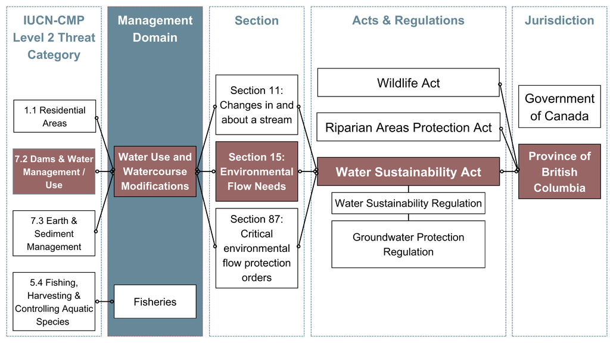

*Figure 2. Relationship between management domains, IUCN-CMP threat categories, and Canadian legislation.*

| Management Domain | IUCN–CMP Level 2 |
| --- | --- |
| Agriculture | 2.1 Annual & Perennial Non-Timber Crops |
| Aquaculture and Hatcheries | 2.4 Marine & Freshwater Aquaculture; 8.3 Introduced Genetic Material |
| Climate Change and Natural Disasters | 10.1 Geological Events; 11.2 Changes in Temperature Regimes; 11.3 Changes in Precipitation & Hydrological Regimes |
| Fisheries | 5.4 Fishing, Harvesting & Controlling Aquatic Species |
| Forest and Range | 2.2 Wood & Pulp Plantations; 2.3 Terrestrial Animal Farming, Ranching & Herding; 5.3 Logging, Harvesting & Controlling Trees |
| Governance Administration | N/A |
| Human Disturbance | 6.3 Other Human Disturbances |
| Invasive or Problematic Species and Disease | 8.1 Invasive Non-Native / Alien Species; 8.2 Problematic Native Species; 8.4 Pathogens |
| Mining and Energy | 3.1 Oil & Gas Exploration & Extraction; 3.2 Mining & Quarrying; 3.3 Renewable Energy |
| Pollution | 9.1 Water-Borne & Other Effluent Pollution; 9.2 Garbage & Solid Waste |
| Restoration | N/A |
| Spatial Designation | N/A |
| Species Status and Assessment | N/A |
| Transportation Infrastructure | 4.1 Roads, Trails & Railroads; 4.2 Utility & Service Lines; 4.3 Shipping Lanes |
| Water Use and Watercourse Modifications | 1.1 Residential Areas; 7.2 Dams & Water Management / Use; 7.3 Earth & Sediment Management; 7.5 Biological System Management |

# Data sources

## Canadian Legal Information Institute (CanLII)

The primary resource for locating and reviewing Canadian legislation was the **Canadian Legal Information Institute (CanLII)**:

https://www.canlii.org/

CanLII provides a comprehensive, searchable database of federal and provincial legislation. It was used as the entry point for the step-wise keyword search process used to identify relevant statutes. Users can search by keyword within any jurisdiction and view individual keyword occurrences in context within any statute.

## Federal legislation portal

Official HTML files for Canadian federal legislation were downloaded directly from the Department of Justice Canada:

[Consolidated Acts](https://laws-lois.justice.gc.ca/eng/acts/)

Responsible ministers for each federal act were confirmed using the **Table of Public Statutes and Responsible Ministers**:

[Table of Public Statutes and Responsible Ministers](https://laws-lois.justice.gc.ca/PDF/tops/eng/TOPS.pdf)

## British Columbia provincial legislation portal

Official HTML files for BC provincial legislation were downloaded from the BC Laws database:

[Public Statutes and Regulations](https://www.bclaws.gov.bc.ca/civix/content/complete/statreg/?xsl=/templates/browse.xsl)

Responsible ministers for each provincial act were confirmed using the **Acts – Ministers’ Responsibilities** resource:

[Acts – Ministers’ Responsibilities](https://www.bclaws.gov.bc.ca/civix/content/amr/amr/2067365574/?xsl=/templates/browse.xsl)

## IUCN–CMP Direct Threats Classification

The categorization framework used to classify management domains and match legislative clauses to anthropogenic threats is the **IUCN–CMP Direct Threats Classification Version 4.0** (Salafsky et al. 2024):

[IUCN–CMP v4.0 by threat (Google Sheets)](https://docs.google.com/spreadsheets/d/1yfm7ua9hQJpjycx6FYQJ6Jy5LA4bP0XP61EW3-sX8ZY/edit?gid=179026760#gid=179026760)

# LAPSE process overview

## Workflow pipeline

The LAPSE process follows a workflow pipeline from legislation collection through to the interactive dashboard. Steps within that workflow pipeline can be broken down into four phases (Figure 1).

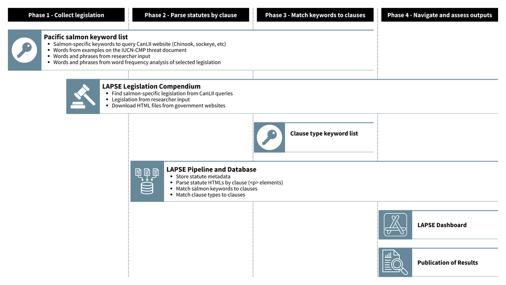

*Figure 1. The LAPSE workflow pipeline.*

**Phase 1 — Collect legislation.** Relevant Canadian federal and British Columbia provincial legislation is identified through a step-wise keyword search on CanLII, beginning with Pacific salmon-specific terms and expanding outward through word frequency analyses, IUCN-CMP threat terminologym, and researcher input. HTML files for all relevant statutes are downloaded directly from the federal and BC provincial legislation portals. The result is 196 statutes (87 federal, 109 provincial) stored in `data/legislation_html/`.

**Phase 2 — Parse statutes by clause.** Two R scripts convert the raw HTML files into structured SQLite tables. `01_database_legislation.R` extracts metadata (jurisdiction, legislation type, act name) from each file’s HTML structure. `02_database_paragraphs.R` parses each statute clause-by-clause, extracting paragraph text, section numbers, and headings while filtering out footnotes, amendment references, and editorial sections. Outputs are the `LegislationMetadata` and `LegislationParagraphs` tables in `output/legislation.db`.

**Phase 3 — Match keywords to clauses.** Five keyword CSV files are developed and refined through an iterative process drawing on IUCN–CMP threat definitions, word frequency analyses of collected legislation, and researcher expert judgment. Keywords are reviewed and revised continuously — single-word ambiguities are replaced with more specific bigrams or trigrams, domain-irrelevant terms are removed, and salmon-relevant terms absent from IUCN-CMP definitions (e.g., *riparian*) are added manually.

`03_database_labels.R` tokenizes all paragraph and heading text using `quanteda`, compounds multi-word keyword phrases (longest-first), then matches four keyword lists independently against each clause. IUCN labels are automatically duplicated as their corresponding Management Domain labels via a lookup table. Scope values (1–4) are assigned to each label row. After deduplication, all results are written to the `paragraph_label_table`.

**Phase 4 — Navigate and assess outputs.** The complete `legislation.db`database is served through the LAPSE Dashboard, a React-based static web application hosted on GitHub Pages. The dashboard reads CSV exports from the pipeline and assembles them client-side into a three-panel interface: a left sidebar for navigating and searching by management domain, a center panel for browsing filtered legislation, and a right panel for dynamic visualizations and clause-level sub-filters. Results are displayed at the section level to preserve legislative context, with matched keywords highlighted in the paragraph text.

Users can filter simultaneously by management domain, jurisdiction, act, regulation, free-text keyword, clause type, actionable type, responsible official, and discretion type. All filters apply AND logic and reset hierarchically when a higher-level selection changes. A direct link to the source statute on the federal or provincial legislation portal is provided when a specific act or regulation is selected. Filtered results can be downloaded as XLSX for offline analysis.

# Phase 1 - LAPSE legislation compendium

## Jurisdictions and legislation types

The LAPSE framework covers two jurisdictions: the **Government of Canada** (federal) and the **Province of British Columbia** (provincial). Four legislation types are included:

Legislation types included in LAPSE.

| Type | Description |
| --- | --- |
| Act | Primary statute passed by Parliament or the Legislative Assembly |
| Regulation | Subordinate legislation made under the authority of an act |
| Order | Ministerial or Governor-in-Council orders made under an act |
| Code | Codes of practice with binding status under an act |

A total of 196 statutes were collected for this study:

Count of legislation by jurisdiction and type.

| Jurisdiction | Acts | Regulations | Orders | Codes | Total |
| --- | --- | --- | --- | --- | --- |
| Federal | 29 | 51 | 7 | 0 | 87 |
| Provincial | 44 | 63 | 0 | 2 | 109 |
| Total | 73 | 114 | 7 | 2 | 196 |

## Legislation Collection Process

### Overview of the collection workflow

Relevant legislation was compiled through a step-wise keyword search process using CanLII, designed to be publicly accessible, automated, and repeatable as legislation changes over time. The collection steps were:

1. Query Pacific salmon-specific terms in CanLII (e.g., *salmon*, *Chinook*, *sockeye*, *coho*)
2. Extract additional adjacent keywords from salmon-specific legislation using word frequency analysis
3. Query extracted keywords and IUCN-CMP threat description wording in CanLII to find adjacent legislation
4. Filter results regionally (excluding provinces other than BC)
5. Download HTML files for relevant legislation directly from government portals

### Word frequency extraction for adjacent keywords

Popular modern biologist language may not appear in legal text due to the age and generality of legislation. To capture salmon-relevant terms that actually occur in statutes, a word frequency analysis was performed on salmon-specific legislation using the **`udpipe`** R package (Wijffels 2025), extracting unigrams, bigrams, and trigrams that co-occur adjacent to salmon-specific terms. These extracted keywords were combined with wording from the IUCN–CMP Direct Threats Classification 4.0 and queried in CanLII to identify additional relevant legislation. This process also created an iterative salmon keyword list that to be used in the keyword matching process.

### Verification via CanLII

Through the CanLII website, individual keywords can be queried within any chosen statute, allowing users to quickly assess the context of a keyword in the legislation and determine whether a section is relevant to Pacific salmon stewardship. This verification step was applied during collection to screen out statutes where keyword matches occurred in contexts unrelated to salmon.

# Phase 2 - Parsing statutes and database structure

## Extracting legislation metadata

*Script: `01_database_legislation.R`* Jurisdiction was determined automatically from HTML metadata in each downloaded file: federal legislation was identified by the `meta[name='description']` tag containing `"Federal laws of Canada"`, while provincial legislation was identified by the `meta[name='breadcrumb']` tag containing `"British Columbia"`. Legislation type (Act, Regulation, Order, Code) was inferred from the legislation name using pattern matching on terms “Regulation/Regulations”, “Order”, “Act”, and “Code”. For non-Act statutes, the parent act name was extracted from the HTML enabling-act element (`p.EnablingAct a` or `div#actname h2`). Responsible ministers were assigned using:

- **Federal:** *Table of Public Statutes and Responsible Ministers* (Department of Justice Canada 2026)
- **Provincial:** *Acts – Ministers’ Responsibilities* (Province of British Columbia 2025)

## Legistics and the clause as the unit of analysis

The individual **clause** was used as the sample unit for assignment into management domains and other attributes. Typological device structure and definitions were derived from the Government of Canada’s **Legistics Paragraphing** guide:

https://www.justice.gc.ca/eng/rp-pr/csj-sjc/legis-redact/legistics/p3p1.html

“Clause” in this study refers to individual HTML paragraph elements (`<p>`), which may correspond to subclauses, sections, subsections, or opening words (chapeau or umbrella text). The hierarchy of elements from largest to smallest is: **heading → section → subsection → clause → subclause**.

## Processing pipeline

The full categorization pipeline is implemented across four sequential R scripts:

R scripts implementing the LAPSE processing pipeline in execution order.

| Script | Purpose | Key Packages |
| --- | --- | --- |
| 01_database_legislation.R | Extract legislation metadata from HTML files and write LegislationMetadata table to SQLite | xml2, rvest, stringi, stringr, RSQLite, data.table |
| 02_database_paragraphs.R | Parse HTML files clause-by-clause, apply content filters, extract section numbers and headings, write LegislationParagraphs table | xml2, rvest, stringi, stringr, RSQLite, data.table |
| 03_database_labels.R | Tokenize paragraph and heading text, match all keyword categories, assign scope, deduplicate, write paragraph_label_table and keyword lookup tables | quanteda, RSQLite, data.table, stringr |
| 05_actionable_clauses.R | Apply multi-step filtering pipeline to identify actionable clauses; extract official, discretion, and instrument attributes; write actionable_clauses table and CSV | RSQLite, data.table, stringr |

## HTML parsing with rvest

*Script: `02_database_paragraphs.R`*

Legislation on Canadian and BC government websites is structured such that each clause appears as a separate HTML paragraph element. HTML files were parsed using R and the **`rvest`** package (Wickham 2025), targeting the following node selector to capture the full range of paragraph contexts across legislation formats:

```r
html_nodes("p, div p, dl p, dd p, li p, ul p, dfn p, a p, span p")
```

### Content filtering

Several categories of paragraph content were excluded before writing to the database:

Content filtering rules applied during HTML parsing (02_database_paragraphs.R).

| Filter | Description |
| --- | --- |
| Footer / metadata | Paragraphs matching patterns such as "King's Printer", "Queen's Printer", "Copyright ©", "Victoria, British Columbia, Canada", and numeric-only text under 5 characters. |
| Amendment references | Paragraphs fully enclosed in square brackets (e.g., [am. B.C. Reg. ...], [en. ...], [Repealed ...]) or matching statute citation patterns such as S.C. 2001, c. 26 and S.B.C. formats. |
| Editorial headings | Paragraphs under headings indicating non-legislative editorial content are excluded. Affected headings include: RELATED PROVISIONS, AMENDMENTS NOT IN FORCE, TRANSITIONAL PROVISIONS, COMING INTO FORCE,… |
| Repeal / revocation language | Paragraphs containing the words repeal, repealed, revoked, Marginal note, or Not in force are removed in a post-processing filter pass. |
| No section number | Paragraphs to which no section number could be assigned by any of the four extraction strategies are excluded. |

## SQLite database schema

The parsed legislation is stored in a **SQLite** database (`output/legislation.db`). Using a relational database rather than a single spreadsheet allows for dynamic querying and streamlines the parsing and collection process. The database contains the following primary tables:

### LegislationMetadata

*Populated by `01_database_legislation.R`*

Fields in the LegislationMetadata table.

| Field | Type | Description |
| --- | --- | --- |
| legislation_id | INTEGER | Unique integer identifier assigned by HTML file processing order |
| jurisdiction | TEXT | Federal or Provincial; determined from HTML meta tags |
| legislation_type | TEXT | Act, Regulations, Order, or Code; inferred from legislation name by pattern matching |
| act_name | TEXT | Name of the parent act; for non-Act statutes extracted from the HTML enabling-act element (p.EnablingAct a or div#actname h2); title-cased and stripped of parenthetical year annotations |
| legislation_name | TEXT | Full name of the statute derived from the HTML filename (underscores replaced with spaces) |

### LegislationParagraphs

*Populated by `02_database_paragraphs.R`*

Fields in the LegislationParagraphs table.

| Field | Type | Description |
| --- | --- | --- |
| paragraph_id | INTEGER | Unique integer identifier assigned sequentially after all files are processed (.I in data.table) |
| legislation_id | INTEGER | Foreign key linking to LegislationMetadata |
| Section | TEXT | Section number or identifier; may include a Schedule or Appendix prefix (e.g., A-3 for section 3 of Schedule A) |
| Heading | TEXT | Text of the nearest preceding heading element (MarginalNote, h4, h3, or h2); the editorial prefix 'Marginal note:' is stripped |
| Paragraph | TEXT | Full UTF-8 text content of the clause paragraph after encoding normalization |

### paragraph_label_table

*Populated by `03_database_labels.R`*

Fields in the paragraph_label_table.

| Field | Type | Description |
| --- | --- | --- |
| paragraph_id | INTEGER | Foreign key linking to LegislationParagraphs |
| label_type | TEXT | Category type: IUCN, Management Domain, Salmon Scope, or Clause Type |
| keyword | TEXT | The matched keyword or keyphrase, normalized to lowercase with whitespace collapsed |
| label_value | TEXT | Assigned category value (e.g., '9.1 Water-Borne & Other Effluent Pollution', 'Pollution', '3 - Habitat', 'Prohibition, Restriction, or Limitation'). Original case is preserved for label values. |
| scope | TEXT | Scope code (1–4) associated with the matched keyword, derived from the management_domain_threat_table or keyword CSV scope columns |
| label_id | INTEGER | Unique integer row identifier assigned after deduplication (.I in data.table) |

### Keyword lookup tables

*Populated by `03_database_labels.R`*

The following keyword CSV files are also written to the SQLite database during the labelling process, providing a complete, queryable record of all keywords used:

Keyword lookup tables stored in the SQLite database.

| Table | Source File | Purpose |
| --- | --- | --- |
| iucn_l2_keywords | data/iucn_l2_keywords.csv | Keywords and keyphrases linking to IUCN–CMP Level 2 threat label values |
| governance_keywords | data/governance_keywords.csv | Keywords and keyphrases linking to Management Domain label values |
| salmon_scope_keywords | data/salmon_scope_keywords.csv | Keywords linking to Salmon Scope categories (1–4) |
| clause_type_keywords | data/clause_type_keywords.csv | Keywords and keyphrases linking to Clause Type label values |
| management_domain_threat_table | data/management_domain_threat_table.csv | Lookup table mapping each IUCN Level 2 threat to its Management Domain and scope value; used to duplicate IUCN labels as Management Domain labels |
| actionable_clause_keywords | (written to database separately) | Two-category keyword table (responsible official; discretionary language) used in actionable clause filtering |

# Phase 3 - Keyword matching and clause labelling

## Keyword and keyphrase development

### Sources of keywords

The management domain and IUCN–CMP threat matching process pivoted around established lists of keywords and phrases. Keywords must be specific enough to match an IUCN–CMP threat, yet general enough to appear across multiple acts and regulations spanning many decades of legal language. Keywords were derived from three sources:

1. **IUCN–CMP Direct Threats Classification 4.0** examples and definitions (Salafsky et al. 2024)
2. **Word frequency analyses** (unigrams, bigrams, and trigrams) of all collected legislation, performed using the `udpipe` R package (Wijffels 2025)
3. **Iterative researcher input and revision** based on domain expertise in Pacific salmon stewardship

The full keyword and keyphrase lists by management domain and clause type are available in Appendix II and Appendix III of the primary publication and in the `data/` directory of the project repository.

### Iterative revision process

Keyword development requires iterative researcher revision because of the varied context of natural language. Words used in IUCN–CMP threat definitions may be irrelevant to salmon stewardship in the legislative context, and single words in particular can have multiple meanings leading to over-assignment of categories. Two illustrative examples from the primary publication:

- **Removed keyword — “landfill”:** Listed in IUCN–CMP examples for *1.2 Commercial & Industrial Areas* in the context of the physical footprint of landfill sites. In collected legislation, “landfill” appears primarily in effluent and water pollution contexts, which are better classified under Pollution. Including it added many clauses outside the tool’s scope, so it was removed.
- **Added keyword — “riparian”:** Highly relevant to salmon habitat stewardship in BC, yet absent from IUCN–CMP threat examples and word frequency analyses of other legislation. Added solely from researchers’ expert judgment.

### Managing ambiguous keywords

Single-word keywords can cause mis-categorization in unexpected ways. For example, “stock” is important for the Fisheries management domain (referring to salmon populations) but also appears in the context of business holdings, freight cars, and livestock. To address this, outputs were reviewed iteratively and keyword revision was a continuous process to:

- find more accurate bigram or trigram alternatives that reduce false positives (e.g., *“fish stock”*, *“salmon stock”*)
- remove keywords where clauses are already matched via more specific alternatives
- capture relevant word variations (plural, past tense, possessive)

## Tokenization and keyword matching

*Script: `03_database_labels.R`*

Keyword matching is performed using the **`quanteda`** package (Benoit et al. 2018) rather than simple text search. This allows multi-word phrases (bigrams, trigrams) to be matched as compound tokens before single-word matching is applied, preventing shorter keywords from consuming parts of longer, more specific phrases.

All keyword CSV files are pre-sorted by decreasing keyword length before compounding, so that the most specific phrases are matched first. The matching process is applied independently to **both paragraph text and heading text** for each clause, then the resulting label rows are combined and deduplicated. This ensures that management domain labels are captured even when the relevant terminology appears only in the section heading and not in the clause body.

## Salmon-specific scope

A **scope** classification categorizes each matched clause by its directness of application to Pacific salmon, determined by the matched keyword. Scope is stored per label row in the `paragraph_label_table`.

Salmon-specific scope categories, keyword sources, and definitions.

| Scope | Keyword Source | Definition |
| --- | --- | --- |
| 1 – Salmon | salmon_scope_keywords.csv | Refers to Pacific salmon specifically (e.g., salmon, Chinook, sockeye, coho). Assigned based solely on salmon scope keywords, independently of management domain. |
| 2 – Fish | iucn_l2_keywords.csv / management_domain_threat_table.csv | Refers to fish that include salmon. Aligns to IUCN threats via scope value in management_domain_threat_table, unless clause is already Scope 1. |
| 3 – Habitat | iucn_l2_keywords.csv / management_domain_threat_table.csv | Refers to any habitat that includes salmon habitat (e.g., watercourse, riparian, watershed). Aligns to IUCN threats via scope value in management_domain_threat_table, unless already Scope 1 or 2. |
| 4 – Governance | governance_keywords.csv | Refers to administrative processes and governance structure. Applied in a separate matching pass using governance_keywords.csv. |

## Clause type classification

The legal character and intent of each clause is classified by **clause type**, enabling users to filter to, for example, all prohibition clauses within a given management domain. Clause type keywords are provided in `data/clause_type_keywords.csv`.

Clause type categories, abbreviations, and descriptions.

| Clause Type | Description |
| --- | --- |
| Administration, Application, & Structure | Establishes procedural rules, administrative structure, or the application of an act |
| Authorization & Mandate | Grants a minister or official the authority or duty to act |
| Designation | Establishes or modifies a spatial area, zone, class, or category |
| Instruction | Requires a person or entity to take or refrain from a specific action |
| Interpretation & Purpose | Defines terms or states the purpose of an act or section |
| Licence, Permitting, & Exemptions | Establishes licence or permit systems, or provides exemptions from requirements |
| Prohibition, Restriction, or Limitation | Prohibits or limits a specific action or activity |

Like management domains, clause types can co-occur within a single clause — a clause may simultaneously receive Authorization and Instruction labels if keywords for both are present.

## Actionable clause filtering

*Script: `05_actionable_clauses.R`*

A subset of clauses was further filtered to identify **actionable clauses** — defined as clauses that authorize or instruct an official to create or establish a regulatory product (e.g., a water licence, land designation, or management plan). This subset is useful for identifying specific legislative tools that could be invoked to address a given salmon threat. The process applies the following steps in sequence:

Actionable clause filtering pipeline steps applied in sequence by 05_actionable_clauses.R.

[output not shown]

# Phase 4 - Navigating and assessing outputs

## Overview

*App: LAPSE Dashboard (`App.tsx` and supporting components)*

The LAPSE Dashboard is a React-based static web application that serves as the primary interface for exploring the outputs of the LAPSE pipeline. It is hosted on GitHub Pages and requires no server or database at runtime:

https://dfo-pacific-science.github.io/LAPSE_dashboard/

The dashboard source code is maintained separately from the pipeline:

https://github.com/dfo-pacific-science/LAPSE_dashboard

## Data inputs

Rather than querying the SQLite database directly, the dashboard reads four flat CSV files exported from the pipeline and assembles them client-side into a fully indexed, filterable interface. The dashboard loads four CSV files from the `public/` directory of the deployed site. These files are generated at the end of the LAPSE pipeline and must be re-exported and redeployed when the database is updated. All filtering, search, and aggregation logic runs in the browser using memorized data structures derived from the loaded CSVs.

CSV files consumed by the LAPSE Dashboard and their pipeline sources.

[output not shown]

Source legislation URLs are stored in `legislation_output.csv` and joined to paragraph records client-side, enabling direct links from any selected act or regulation to its source on the federal or BC provincial legislation portal.

## Interface layout

The dashboard is organized into a fixed header, a collapsible info bar, and a three-column main panel.

### Header

The header displays the full LAPSE title and an **About** button that opens a modal with version information, a data dictionary, and deployment help.

### Dashboard info bar

A collapsible bar below the header displays four persistent elements: (1) a collapsible disclaimer noting that LAPSE does not constitute legal advice; (2) the date the CSV data was last processed by the pipeline; (3) the total count of unique statutes in the loaded dataset; and (4) quick-link cards to the LAPSE About page and this Technical Brief.

### Left sidebar — Management domain navigation

The left sidebar lists all 15 management domains with a keyword-match count for each, sorted by count in descending order. Counts reflect only the data visible under the current jurisdiction, act, and legislation filters, updating dynamically as those filters change. Selecting a domain narrows the centre and right panels to clauses tagged to that domain. A **keyword search bar** also resides in the sidebar; search is applied across the `act_name`, `legislation_name`, `heading`, and `paragraph` fields simultaneously. On viewports narrower than the large breakpoint, the sidebar is replaced by a compact dropdown selector.

### Centre panel — Legislation panel

The centre panel contains two stacked sections: the filter controls (described below) and the clause results list. Clauses are displayed at the **section level** — if any paragraph within a section passes all active filters, the full section is shown to preserve legislative context. Matched keywords are highlighted in the paragraph text. When a specific act or regulation is selected, a **View Full Legislation** button links directly to the source statute on the relevant government portal.

### Right panel — Results and visualizations

The right panel contains a **Download XLSX** button, dynamic summary visualizations, and the clause-level sub-filter controls. All chart content and sub-filter option counts update in real time as filters change. The panel is always visible alongside the centre panel on desktop viewports.

## Filtering system

Filters are applied with AND logic across all active criteria. The nine available filters are:

Dashboard filter controls, their location in the interface, and their behaviour.

[output not shown]

A **Reset All Filters** button in the centre panel returns all controls to their default state simultaneously.

## Export

Filtered results are exported as an XLSX file via the **Download XLSX** button in the right panel. The exported file contains one row per clause and includes all fields from `paragraph_output.csv` for every row passing the active filters. The filename is automatically dated (`LAPSE_Export_YYYY-MM-DD.xlsx`). Export is disabled when no clauses are returned by the current filter combination.

# Reproducibility and Versioning

## Repeatability by design

The LAPSE process was designed to be publicly accessible, automated, and repeatable as legislation changes over time. The collection and parsing pipeline can be re-run to update the database when new legislation is enacted, existing legislation is amended, IUCN–CMP threat categories are updated, or keyword lists are revised. All scripts, keyword CSV files, and the SQLite database are version-controlled in the project GitHub repository:

https://github.com/dfo-pacific-science/LAPSE_pipeline

## R packages required

R packages used in the LAPSE pipeline.

| Package | Use |
| --- | --- |
| rvest | HTML parsing of legislation files — node selection, text extraction |
| xml2 | Low-level XML/HTML node access and XPath evaluation |
| quanteda | Tokenization, multi-word phrase compounding, and keyword matching for category assignment |
| udpipe | Word frequency analysis (unigrams, bigrams, trigrams) for adjacent keyword extraction during collection |
| data.table | Efficient in-memory data manipulation, batch processing, and data.table joins |
| RSQLite | SQLite database read/write for all pipeline inputs and outputs |
| DBI | Database connection interface |
| stringr | String manipulation, regex pattern matching, and whitespace normalization |
| stringi | UTF-8 encoding detection, conversion, and transliteration (stri_enc_toutf8, stri_trans_general) |
| here | Reproducible relative file path management across operating systems |
| DiagrammeR | Process flowchart and network diagram rendering via Graphviz (this document) |
| flextable | Table formatting in rendered HTML output (this document) |
| networkD3 | Sankey diagram visualization for legislation-to-ministry alluvial plots |
| ggplot2 | Static chart and bar plot visualization |
| beepr | Audio notification on pipeline completion |

## Transparency of researcher subjectivity

Researcher subjectivity influences the process at two primary points: (1) decisions about whether a given statute is relevant to Pacific salmon stewardship (legislation inclusion), and (2) decisions about which keywords to include, remove, or modify (keyword list development). Using explicit, documented keyword lists allows this subjectivity to be acknowledged, reported, and reproduced. The keyword CSV files are available in the `data/` directory of the repository, enabling other researchers to review decisions, propose revisions, and re-run the process with alternative keyword configurations.

# Known Limitations

**1. Keyword-based matching is not semantic.** Keyword matching identifies the presence of a term but does not parse legal intent or the surrounding sentence structure. A keyword may appear in an unrelated context. Iterative review and bigram/trigram refinement mitigate but do not eliminate this issue.

**2. Word frequency does not reflect regulatory effectiveness.** The count of statutes, sections, or clauses matched to a management domain is not a measure of the quality or effectiveness of legislation (Ray et al. 2021). A management domain with many matched clauses may still have weak or discretionary regulatory coverage.

**3. Implementation and enforcement are not assessed.** This study reports legislation as written. It does not verify whether responsible agencies actively implement or enforce provisions, nor does it assess the adequacy of resources or capacity available to do so.

**4. Policy is excluded.** Departmental policy frameworks (e.g., DFO’s Wild Salmon Policy) are not included, despite significantly shaping how legislation is applied in practice.

**5. Scope of jurisdictions.** Indigenous legislation, Yukon legislation, municipal bylaws, and international conventions are not included, despite their importance to Pacific salmon stewardship.

**6. Legislation updates.** HTML files were downloaded from government portals at a specific point in time. Legislation is periodically amended and consolidated; users should verify that referenced legislation reflects the current consolidated version.

# Bibliography

Arbeider, M., Ritchie, L., Braun, D., Jenewein, B., Rickards, K., Dionne, K., Holt, C., Labelle, M., Nicklin, P., Mozin, P., Grant, P., Parken, C., and Bailey, R. 2020. Interior Fraser Coho Salmon Recovery Potential Assessment. Fisheries and Oceans Canada.

Atkinson, E.M., Carturan, B.S., Atkinson, C.P., Bateman, A.W., Connors, K., Hertz, E., and Peacock, S.J. 2024. Monitoring for fisheries or for fish? Declines in monitoring of salmon spawners continue despite a conservation crisis. doi:10.1101/2024.12.01.626233.

Bankes, N., Mascher, S., and Olszynski, M. 2014. Can Environmental Laws Fulfill Their Promise? Stories from Canada. Sustainability 6(9): 6024–6048. doi:10.3390/su6096024.

Becklumb, P. 2013. Federal and Provincial Jurisdiction to Regulate Environmental Issues. Library of Parliament, Canada, Ottawa, ON.

Benoit, K., Watanabe, K., Wang, H., Nulty, P., Obeng, A., Müller, S., and Matsuo, A. 2018. quanteda: An R package for the quantitative analysis of textual data. Journal of Open Source Software 3(30): 774. doi:10.21105/joss.00774.

Bisson, P.A., Dunham, J.B., and Reeves, G.H. 2009. Freshwater Ecosystems and Resilience of Pacific Salmon: Habitat Management Based on Natural Variability. E&S 14(1): art45. doi:10.5751/ES-02784-140145.

Bogetti, J.M., and Mason, C.W. 2025. To protect or forget? Comparing species at risk legislation across Canada’s common-law provinces. FACETS 10: 1–11. doi:10.1139/facets-2025-0031.

Campbell, M.L., and Thomas, V.G. 2002. Constitutional Impacts on Conservation: Effects of Federalism on Biodiversity Protection. Environmental Policy and Law 32(5): 223–232. doi:10.3233/EPL-2002-32_5_13.

Canadian Legal Information Institute. 2025. CanLII. Available from https://www.canlii.org/ [accessed 18 December 2025].

Chalifour, L., Holt, C., Camaclang, A.E., Bradford, M.J., Dixon, R., Finn, R.J.R., Hemming, V., Hinch, S.G., Levings, C.D., MacDuffee, M., Nishimura, D.J.H., Pearson, M., Reynolds, J.D., Scott, D.C., Spremberg, U., Stark, S., Stevens, J., Baum, J.K., and Martin, T.G. 2022. Identifying a pathway towards recovery for depleted wild Pacific salmon populations in a large watershed under multiple stressors. Journal of Applied Ecology 59(9): 2212–2226. doi:10.1111/1365-2664.14239.

Cohen, B.I. 2012. Commission of Inquiry into the Decline of Sockeye Salmon in the Fraser River (Canada): The uncertain future of Fraser River sockeye. Privy Council Office, Ottawa, ON.

Collins, L., and Sossin, L. 2019. Approach to Constitutional Principles and Environmental Discretion in Canada. Articles & Book Chapters 52(2740).

COSEWIC. 2023. COSEWIC guidelines for recognizing designatable units. Canadian Wildlife Service, Environment and Climate Change Canada, Gatineau, QC.

Dallimer, M., and Strange, N. 2015. Why socio-political borders and boundaries matter in conservation. Trends in Ecology & Evolution 30(3): 132–139. doi:10.1016/j.tree.2014.12.004.

Del Valle, E., Neal, B., Martínez-Candelas, I., Dann, P., Webb, D., and McClenachan, L. 2024. Fishing in turbulent waters: Resilience, risk, and trust in British Columbia’s declining commercial salmon fishery. FACETS 9: 1–17. doi:10.1139/facets-2023-0204.

Department of Justice Canada. 2022. Legistics Paragraphing. Available from https://www.justice.gc.ca/eng/rp-pr/csj-sjc/legis-redact/legistics/p3p1.html [accessed 18 December 2025].

Department of Justice Canada. 2026. Table of Public Statutes and Responsible Ministers. Available from https://laws-lois.justice.gc.ca/PDF/tops/eng/TOPS.pdf [accessed 13 January 2026].

DFO. 2005. Canada’s Policy for Conservation of Wild Pacific Salmon. Fisheries and Oceans Canada, Vancouver, BC.

DFO. 2019. Recovery Potential Assessment – Cultus Lake Sockeye Salmon (*Oncorhynchus nerka*). Science Advisory Report 2020/011. Canadian Science Advisory Secretariat.

DFO. 2020. Recovery Potential Assessment for 11 Designatable Units of Fraser River Chinook salmon, *Oncorhynchus tshawytcha*, Part 1: Elements 1 to 11. DFO Can. Sci. Advis. Sec. Sci. Advis. Rep.

DFO. 2021. Wild Salmon Policy: 2018–2022 Implementation Plan, Annual Report 2020–21. Fisheries and Oceans Canada, Vancouver, BC.

DFO. 2022a. Guidelines for writing rebuilding plans per the Fish Stocks Provisions and A Fishery Decision-making Framework Incorporating the Precautionary Approach. Fisheries and Oceans Canada, Ottawa, ON.

DFO. 2022b. Rebuilding plan: Okanagan Chinook Salmon [*Oncorhynchus tshawytscha*]. Fisheries and Oceans Canada, Ottawa, ON.

DFO. 2024. Trilateral declaration on the urgent need to address wild Pacific salmon populations in British Columbia. Fisheries and Oceans Canada.

DFO. 2025. Rebuilding plan: West Coast of Vancouver Island Chinook, *Oncorhynchus tshawystcha*. Fisheries and Oceans Canada, Vancouver, BC.

Dionne, K. 2023. Recovery potential assessment for southern British Columbian chinook populations, Fraser and southern mainland chinook designatable units (1, 6, 13 and 15). Canadian Science Advisory Secretariat (CSAS), Ottawa, ON.

Doutaz, D., Huang, A.-M., Decker, S., and Vivian, T. 2023. Recovery potential assessment for Fraser River sockeye salmon (*Oncorhynchus nerka*), nine designatable units part 2. Canadian Science Advisory Secretariat (CSAS), Ottawa, ON.

Government of British Columbia. 2002. Forest and Range Practices Act.

Government of Canada. 2005. Order Giving Notice of Decisions not to add Certain Species to the List of Endangered Species.

Grant, S.C.H., MacDonald, B.L., and Winston, M.L. 2019. State of the Canadian Pacific salmon: Response to changing climate and habitats. Department of Fisheries and Oceans, Nanaimo, BC.

Kraus, D., Murphy, S., and Armitage, D. 2021. Ten bridges on the road to recovering Canada’s endangered species. FACETS 6: 1088–1127. doi:10.1139/facets-2020-0084.

Mahony, A., Challenger, W., Robichaud, D., Wright, H., Bussanich, R., Sharma, R., and Enns, J. 2019. Recovery Potential Assessment for the Okanagan Chinook Salmon (*Oncorhynchus tshawytscha*) (2019).

Marentette, J.R., and Kronlund, A.R. 2020. A cross-jurisdictional review of international fisheries policies, standards and guidelines. Fisheries and Oceans Canada, Ottawa, ON.

McCleary, R.J., and Thomson, D.A. 2021. Hydrogeology and Environmental Flow Needs Assessment of a Groundwater Licence Application near Lumby, B.C. Province of British Columbia, Victoria, BC.

McCune, J.L., Harrower, W.L., Avery-Gomm, S., and others. 2013. Threats to Canadian species at risk: An analysis of finalized recovery strategies. Biological Conservation 166: 254–265. doi:10.1016/j.biocon.2013.07.006.

McDonald, K. 2021. Pacific Salmon: Ensuring the Long-term Health of Wild Populations and Associated Fisheries. House of Commons Canada, Ottawa, ON.

Minister of Justice Canada. 1985. Fisheries Act.

Moore, J.W., Ulaski, M.E., Wilson, K.L., Martin, T.G., and others. 2025. A Safe Operating Space for Salmon Watersheds Under Rapid Climate Change. Fish and Fisheries 26(6): 1213–1228. doi:10.1111/faf.70027.

Price, M.H.H., English, K.K., Rosenberger, A.G., MacDuffee, M., and Reynolds, J.D. 2017. Canada’s Wild Salmon Policy: An assessment of conservation progress in British Columbia. Can. J. Fish. Aquat. Sci. 74(10): 1507–1518. doi:10.1139/cjfas-2017-0127.

Province of British Columbia. 2025. Acts – Ministers’ Responsibilities. Government of British Columbia.

Ramshaw, B., Luedke, W., and Korman, J. 2019. Recovery Potential Assessment for the Sakinaw Lake Sockeye Salmon (*Oncorhynchus nerka*) (2017). DFO Can. Sci. Advis. Sec. Res. Doc.

Ray, J.C., Grimm, J., and Olive, A. 2021. The biodiversity crisis in Canada: Failures and challenges of federal and sub-national strategic and legal frameworks. FACETS 6: 1044–1068. doi:10.1139/facets-2020-0075.

Salafsky, N., Relton, C., Young, B.E., and others. 2024. Classification of direct threats to the conservation of ecosystems and species 4.0. Conservation Biology 39(3): e14434. doi:10.1111/cobi.14434.

Salafsky, N., Salzer, D., Stattersfield, A.J., and others. 2008. A Standard Lexicon for Biodiversity Conservation: Unified Classifications of Threats and Actions. Conservation Biology 22(4): 897–911. doi:10.1111/j.1523-1739.2008.00937.x.

Swerdfager, T., and Olive, A. 2023. Laws matter: A foundational approach to biodiversity conservation in Canada. FACETS 8: 1–13. doi:10.1139/facets-2022-0095.

Thompson, P.C. 1974. Institutional Constraints in Fisheries Management. J. Fish. Res. Board Can 31: 1965–1981.

Turcotte, A., Kermany, N., Foster, S., and others. 2021. Fixing the Canadian Species at Risk Act. FACETS 6: 1474–1494. doi:10.1139/facets-2020-0064.

Ulaski, M.E., Moore, J.W., Carlson, D., and others. 2025. Barriers and opportunities for the effective management of cumulative effects in salmon ecosystems in British Columbia, Canada. FACETS 10: 1–25. doi:10.1139/facets-2024-0348.

Wickham, H. 2025. rvest: Easily Harvest (Scrape) Web Pages. doi:10.32614/CRAN.package.rvest.

Wijffels, J. 2025. udpipe: Tokenization, Parts of Speech Tagging, Lemmatization and Dependency Parsing with the ‘UDPipe’ ‘NLP’ Toolkit. doi:10.32614/CRAN.package.udpipe.